# DMML 2024: Final Project

*Francesco Peria, Maria Paola Sforza Fogliani, Andrea Vitali*

```python
import numpy as np
import pandas as pd
import matplotlib.pyplot as plt
import sklearn
import seaborn as sns
```

```python
pd.set_option('display.max_columns', 100)
df = pd.read_csv('A) Data Understanding & Preparation Output.csv', sep=',', skipinitialspace=True)
df.head()
```

|  | emotion | vocal_channel | emotional_intensity | statement | repetition | sex | length_ms | zero_crossings_sum | mfcc_mean | mfcc_std | mfcc_min | mfcc_max | sc_mean | sc_std | sc_min | sc_max | sc_kur | sc_skew | stft_mean | stft_std | stft_min | stft_kur | stft_skew | std | min | max | kur | skew |
| --- | --- | --- | --- | --- | --- | --- | --- | --- | --- | --- | --- | --- | --- | --- | --- | --- | --- | --- | --- | --- | --- | --- | --- | --- | --- | --- | --- | --- |
| 0 | fearful | 0.0 | 0.0 | 0.0 | 1.0 | 0.0 | 3737.0 | 16995.0 | -33.485947 | 134.654860 | -755.22345 | 171.69092 | 5792.550744 | 3328.055457 | 0.0 | 13541.959028 | -1.120769 | 0.250940 | 0.415250 | 0.335533 | 0.0 | -1.215025 | 0.403514 | 0.014482 | -0.128632 | 0.138947 | 9.406061 | 0.273153 |
| 1 | angry | 0.0 | 0.0 | 0.0 | 0.0 | 0.0 | 3904.0 | 13906.0 | -29.502108 | 130.485630 | -713.98560 | 205.00770 | 5197.620555 | 4040.931570 | 0.0 | 12000.290443 | -1.531204 | 0.219582 | 0.417488 | 0.352380 | 0.0 | -1.384174 | 0.290905 | 0.020417 | -0.305725 | 0.263062 | 19.564187 | 0.292157 |
| 2 | happy | 0.0 | 1.0 | 0.0 | 1.0 | 0.0 | 4671.0 | 18723.0 | -30.532463 | 126.577110 | -726.06036 | 165.45653 | 4830.743037 | 3332.131300 | 0.0 | 12007.751173 | -1.130153 | 0.436699 | 0.379758 | 0.352270 | 0.0 | -1.242947 | 0.470350 | 0.024317 | -0.137482 | 0.166351 | 4.881241 | 0.302659 |
| 3 | surprised | 0.0 | 0.0 | 1.0 | 0.0 | 0.0 | 3637.0 | 11617.0 | -36.059555 | 159.725160 | -842.94635 | 190.03609 | 5376.446478 | 4053.663073 | 0.0 | 12048.223893 | -1.497765 | 0.098802 | 0.407277 | 0.360552 | 0.0 | -1.445318 | 0.274756 | 0.003561 | -0.027374 | 0.024078 | 13.040259 | -0.081014 |
| 4 | happy | 1.0 | 1.0 | 0.0 | 1.0 | 0.0 | 4404.0 | 15137.0 | -31.405996 | 122.125824 | -700.70276 | 161.13400 | 5146.012474 | 3442.724109 | 0.0 | 12025.582707 | -1.167544 | 0.496066 | 0.415974 | 0.350655 | 0.0 | -1.366742 | 0.318926 | 0.027522 | -0.192169 | 0.242676 | 7.485109 | 0.414872 |

```python
df.info()
```

```
<class 'pandas.core.frame.DataFrame'>
RangeIndex: 2452 entries, 0 to 2451
Data columns (total 28 columns):
 #   Column               Non-Null Count  Dtype
---  ------               --------------  -----
 0   emotion              2452 non-null   object
 1   vocal_channel        2452 non-null   float64
 2   emotional_intensity  2452 non-null   float64
 3   statement            2452 non-null   float64
 4   repetition           2452 non-null   float64
 5   sex                  2452 non-null   float64
 6   length_ms            2452 non-null   float64
 7   zero_crossings_sum   2452 non-null   float64
 8   mfcc_mean            2452 non-null   float64
 9   mfcc_std             2452 non-null   float64
```

[output cut: 20 more lines]

# C) Classification

In questa sezione, esploreremo, analizzeremo e valuteremo diversi metodi di classificazione al fine di prevedere due variabili categoriche fondamentali nel nostro dataset: Emotion e Sex.

## Decision Tree on Sex

Iniziamo con il modello chiamato **Decision Tree** che costruisce una struttura ad albero che simula una serie di split logici basati sulle variabili usate per l'addestramento per arrivare a una conclusione sulla variabile target. Per utilizzare il **Decision Tree**, dobbiamo far sì che gli attributi categorici nel nostro dataframe siano trasformati in variabili binarie (0 e 1) per consentire al modello di apprendere da tali attributi. Questo passaggio, chiamato binarizzazione, è già stato fatto per tutti gli attributi categorici del dataset con solo due valori distinti nella sezione di clustering.

Tuttavia, per quanto riguarda l'attributo Emotion, poiché esso presenta più di due valori distinti, adotteremo la tecnica di **one-hot encoding**. Questa tecnica trasforma ciascun valore univoco dell'attributo Emotion in una variabile binaria separata creando una colonna per ogni emozione possibile, come "happy", "sad", "angry", ecc., con valori 1 o 0 a seconda della presenza o assenza di quella specifica emozione in ciascuna osservazione. Questa trasformazione preserva l'integrità delle informazioni categoriche senza introdurre un ordine fittizio tra le categorie.

```python
df_noobj = pd.get_dummies(df, columns=['emotion'])
```

Abbiamo quindi creato un dataframe chiamato **df_noobj** privo di oggetti

```python
df_noobj.dtypes
```

```
vocal_channel          float64
emotional_intensity    float64
statement              float64
repetition             float64
sex                    float64
length_ms              float64
zero_crossings_sum     float64
mfcc_mean              float64
mfcc_std               float64
mfcc_min               float64
mfcc_max               float64
sc_mean                float64
sc_std                 float64
sc_min                 float64
sc_max                 float64
sc_kur                 float64
sc_skew                float64
stft_mean              float64
stft_std               float64
stft_min               float64
stft_kur               float64
stft_skew              float64
std                    float64
min                    float64
max                    float64
kur                    float64
skew                   float64
emotion_angry             bool
emotion_calm              bool
emotion_disgust           bool
emotion_fearful           bool
emotion_happy             bool
emotion_neutral           bool
emotion_sad               bool
emotion_surprised         bool
dtype: object
```

```python
df_noobj
```

|  | vocal_channel | emotional_intensity | statement | repetition | sex | length_ms | zero_crossings_sum | mfcc_mean | mfcc_std | mfcc_min | mfcc_max | sc_mean | sc_std | sc_min | sc_max | sc_kur | sc_skew | stft_mean | stft_std | stft_min | stft_kur | stft_skew | std | min | max | kur | skew | emotion_angry | emotion_calm | … |
| --- | --- | --- | --- | --- | --- | --- | --- | --- | --- | --- | --- | --- | --- | --- | --- | --- | --- | --- | --- | --- | --- | --- | --- | --- | --- | --- | --- | --- | --- | --- |
| 0 | 0.0 | 0.0 | 0.0 | 1.0 | 0.0 | 3737.0 | 16995.0 | -33.485947 | 134.654860 | -755.22345 | 171.69092 | 5792.550744 | 3328.055457 | 0.000000 | 13541.959028 | -1.120769 | 0.250940 | 0.415250 | 0.335533 | 0.000000 | -1.215025 | 0.403514 | 0.014482 | -0.128632 | 0.138947 | 9.406061 | 0.273153 | False | False | … |
| 1 | 0.0 | 0.0 | 0.0 | 0.0 | 0.0 | 3904.0 | 13906.0 | -29.502108 | 130.485630 | -713.98560 | 205.00770 | 5197.620555 | 4040.931570 | 0.000000 | 12000.290443 | -1.531204 | 0.219582 | 0.417488 | 0.352380 | 0.000000 | -1.384174 | 0.290905 | 0.020417 | -0.305725 | 0.263062 | 19.564187 | 0.292157 | True | False | … |
| 2 | 0.0 | 1.0 | 0.0 | 1.0 | 0.0 | 4671.0 | 18723.0 | -30.532463 | 126.577110 | -726.06036 | 165.45653 | 4830.743037 | 3332.131300 | 0.000000 | 12007.751173 | -1.130153 | 0.436699 | 0.379758 | 0.352270 | 0.000000 | -1.242947 | 0.470350 | 0.024317 | -0.137482 | 0.166351 | 4.881241 | 0.302659 | False | False | … |
| 3 | 0.0 | 0.0 | 1.0 | 0.0 | 0.0 | 3637.0 | 11617.0 | -36.059555 | 159.725160 | -842.94635 | 190.03609 | 5376.446478 | 4053.663073 | 0.000000 | 12048.223893 | -1.497765 | 0.098802 | 0.407277 | 0.360552 | 0.000000 | -1.445318 | 0.274756 | 0.003561 | -0.027374 | 0.024078 | 13.040259 | -0.081014 | False | False | … |
| 4 | 1.0 | 1.0 | 0.0 | 1.0 | 0.0 | 4404.0 | 15137.0 | -31.405996 | 122.125824 | -700.70276 | 161.13400 | 5146.012474 | 3442.724109 | 0.000000 | 12025.582707 | -1.167544 | 0.496066 | 0.415974 | 0.350655 | 0.000000 | -1.366742 | 0.318926 | 0.027522 | -0.192169 | 0.242676 | 7.485109 | 0.414872 | False | False | … |
| ... | ... | ... | ... | ... | ... | ... | ... | ... | ... | ... | ... | ... | ... | ... | ... | ... | ... | ... | ... | ... | ... | ... | ... | ... | ... | ... | ... | ... | ... | … |
| 2447 | 0.0 | 1.0 | 1.0 | 0.0 | 1.0 | 4605.0 | 9871.0 | -30.225578 | 158.845500 | -855.92420 | 208.18497 | 5886.647366 | 4114.260257 | 0.000000 | 12210.517144 | -1.588861 | 0.184390 | 0.573838 | 0.304496 | 0.000000 | -1.075888 | -0.310088 | 0.005260 | -0.039856 | 0.052399 | 9.551363 | 0.759247 | False | True | … |
| 2448 | 0.0 | 0.0 | 0.0 | 0.0 | 1.0 | 4171.0 | 8963.0 | -31.160332 | 157.499700 | -825.37410 | 220.79490 | 6602.742127 | 4191.727090 | 0.000000 | 12064.561791 | -1.614582 | -0.113920 | 0.591010 | 0.306333 | 0.000000 | -1.026071 | -0.408018 | 0.006836 | -0.064178 | 0.084045 | 22.517991 | 1.073633 | False | True | … |
| 2449 | 1.0 | 1.0 | 0.0 | 1.0 | 1.0 | 5239.0 | 9765.0 | -26.135280 | 138.133210 | -768.36536 | 235.53938 | 4654.156076 | 4231.511986 | 0.000000 | 12207.179884 | -1.337419 | 0.619346 | 0.467994 | 0.347843 | 0.000000 | -1.473789 | 0.130310 | 0.015384 | -0.093079 | 0.097260 | 4.964319 | -0.005821 | False | False | … |
| 2450 | 0.0 | 0.0 | 1.0 | 0.0 | 1.0 | 3737.0 | 9716.0 | -28.242815 | 159.943400 | -868.09576 | 219.84350 | 5524.736973 | 3596.031841 | 760.822547 | 11981.912464 | -1.465594 | 0.206481 | 0.578854 | 0.308684 | 0.001565 | -1.277117 | -0.242668 | 0.005182 | -0.057556 | 0.052002 | 13.855588 | -0.110966 | False | False | … |
| 2451 | 1.0 | 0.0 | 0.0 | 1.0 | 1.0 | 3837.0 | 9427.0 | -29.019236 | 149.188950 | -799.51010 | 219.52780 | 6082.676123 | 3963.725117 | 0.000000 | 12199.773419 | -1.501387 | 0.147574 | 0.554946 | 0.320787 | 0.000000 | -1.257666 | -0.237757 | 0.010001 | -0.081512 | 0.103027 | 12.973181 | 1.032081 | False | False | … |

2452 rows × 35 columns

Scegliamo come variabile target l'attributo **sex** e prendiamo tutte le altre colonne come quelle che useremo per allenare il modello predittivo del Decision Tree

```python
target = 'sex'
columns = [c for c in df_noobj.columns if c not in target]
```

```python
columns
```

```
['vocal_channel',
 'emotional_intensity',
 'statement',
 'repetition',
 'length_ms',
 'zero_crossings_sum',
 'mfcc_mean',
 'mfcc_std',
 'mfcc_min',
 'mfcc_max',
 'sc_mean',
 'sc_std',
 'sc_min',
 'sc_max',
 'sc_kur',
 'sc_skew',
 'stft_mean',
 'stft_std',
 'stft_min',
 'stft_kur',
 'stft_skew',
 'std',
 'min',
 'max',
 'kur',
 'skew',
 'emotion_angry',
 'emotion_calm',
 'emotion_disgust',
 'emotion_fearful',
 'emotion_happy',
 'emotion_neutral',
 'emotion_sad',
 'emotion_surprised']
```

Splittiamo il dataset in due parti, una riservata al **Training & Validation Set** composta dall'80% dei dati e il **Test Set** composto dal 20% dei dati. All'interno della porzione Training & Validation Set, un 20% viene riservato al Validation Set (16% del totale) e il rimanente al Traning Set (64%). Abbiamo scelto questa proporzione in quanto è una di quelle più comunemente usate nei modelli predittivi, ma successivamente andremo a controllare se esistono partizioni che migliorano il modello. La creazione dei due set è stratificata (con il parametro stratify settato a y) e riproducibile (con il parametro random_state=0). L'importanza di creare un Validation Set che sia indipendente permette di valutare e ottimizzare gli iperparametri del modello senza toccare il Test Set. Questo approccio può aiutare a prevenire l'overfitting sul Test Set.

```python
X = df_noobj[columns].values
y = df_noobj[target].values
```

```python
from sklearn.model_selection import train_test_split
```

```python
X_train_val, X_test, y_train_val, y_test = train_test_split(X, y, test_size=0.2, stratify=y, random_state=0)
```

```python
X_train, X_val, y_train, y_val = train_test_split(X_train_val, y_train_val, test_size=0.2, stratify=y_train_val, random_state=0)
```

```python
from sklearn.tree import DecisionTreeClassifier
```

```python
from sklearn.metrics import accuracy_score, confusion_matrix
```

Dopo aver importato l'algoritmo DecisionTreeClassifier, lo inizializziamo usando il **gini index** per misurare la qualità degli split. In questo primo passaggio, in maniera arbitraria, decidiamo di non mettere un limite alla **profondità dell'albero**, di impostare come 2 **il numero minimo di campioni necessari per splittare un nodo**, e come 1 **il numero minimo di campioni che devono essere inclusi in una foglia**. L'albero viene prima addestrato sul Traning set che abbiamo scelto e successivamente testato sul Validation set. L'accuracy ottenuta è 0.90 che indica che il modello ha predetto correttamente la classe di appartenenza nel 90% dei casi nel set di dati di validazione.

```python
clf = DecisionTreeClassifier(
    criterion='gini',
    max_depth=None,
    min_samples_split=2,
    min_samples_leaf=1,
    ccp_alpha=0.0,
    random_state=0
)
clf.fit(X_train, y_train)

y_pred = clf.predict(X_val)
accuracy_score(y_val, y_pred)
```

```
0.9033078880407125
```

Visualizziamo la **confusion matrix**, dove:

- Nella prima cella (in alto a sinistra) abbiamo i True Positives (TP)
- Nella seconda cella (in alto a destra) abbiamo i False Negatives (FN)
- Nella terza cella (in basso a sinistra) abbiamo i False Positives (FP)
- Nella quarta cella (in basso a destra) abbiamo i True Negatives (TN)

Il numero di TP e TN rispetto al FP e FN rispecchia l'alta accuratezza del modello

```python
confusion_matrix(y_val, y_pred)
```

```
array([[170,  23],
       [ 15, 185]])
```

Con le seguenti due celle di codice valutiamo come varia l'accuratezza al variare della dimensione del Training Set. Dal grafico sembrerebbe che assegnare l'80% del dataset al Training Set dia i risultati migliori per l'accuratezza.

```python
accuracy_mean_list = list()
accuracy_std_list = list()
for p in np.arange(0.1, 1.0, 0.1):
    accuracy_list_p = list()
    for i in range(0, 10):
        index = np.random.choice(np.arange(0, len(X_train)), int(len(X_train) * p), replace=False)
        clf = DecisionTreeClassifier(
            criterion='gini',
            max_depth=None,
            min_samples_split=2,
            min_samples_leaf=1,
            ccp_alpha=0.0,
            random_state=0)
        clf.fit(X_train[index], y_train[index])

        y_pred = clf.predict(X_val)
        accuracy_list_p.append(accuracy_score(y_val, y_pred))
    accuracy_mean_list.append(np.mean(accuracy_list_p))
    accuracy_std_list.append(np.std(accuracy_list_p))
```

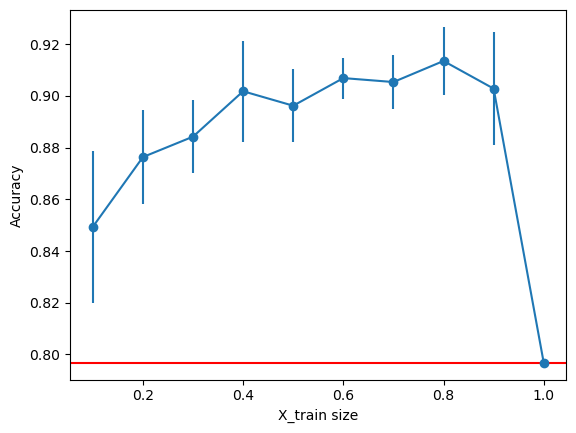

```python
accuracy_mean_list.append(0.7967914438502673)
accuracy_std_list.append(0.0)

plt.errorbar(x=np.arange(0.1, 1.1, 0.1), y=accuracy_mean_list,
             yerr=accuracy_std_list, marker='o')
plt.axhline(y=0.7967914438502673, color='r')
plt.ylabel('Accuracy')
plt.xlabel('X_train size')
plt.show()
```

Nelle seguenti celle andiamo a esplorare come la selezione degli **iperparametri** per il Decision Tree vari l'accuratezza. Ne andremo ad analizzare 3:

1. *il numero minimo di campioni che deve avere ogni foglia dell'albero decisionale*
2. *il numero minimo di campioni necessari perché un nodo sia splittabile*
3. *la massima profondità dell'albero decisionale*.

Con le seguenti due celle di codice valutiamo come varia l'accuratezza con **il numero minimo di campioni che deve avere ogni foglia dell'albero decisionale**. Dal grafico sembrerebbe che i valori di 11 e 12 siano quelli che danno un'accuratezza migliore. Generalmente quando possibile, è preferibile scegliere numeri più alti per evitare overfitting quindi per le successive analisi imposteremo il parametro a 12.

```python
min_sample_leaf_list = np.arange(1, 50+1, 1)
accuracy_val_list = list()
accuracy_train_list = list()
for min_sample_leaf in min_sample_leaf_list:
    clf = DecisionTreeClassifier(
        criterion='gini',
        max_depth=None,
        min_samples_split=2,
        min_samples_leaf=min_sample_leaf,
        ccp_alpha=0.0,
        random_state=0
    )
    clf.fit(X_train, y_train)

    y_pred = clf.predict(X_val)
    accuracy_val_list.append(accuracy_score(y_val, y_pred))

    y_pred_train = clf.predict(X_train)
    accuracy_train_list.append(accuracy_score(y_train, y_pred_train))
```

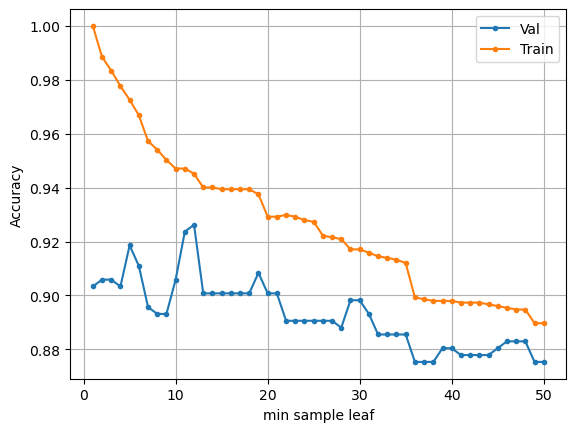

```python
plt.plot(min_sample_leaf_list, accuracy_val_list, label='Val', marker='.')
plt.plot(min_sample_leaf_list, accuracy_train_list, label='Train', marker='.')
plt.ylabel('Accuracy')
plt.xlabel('min sample leaf')
plt.grid('white')
plt.legend()
plt.show()
```

Con le seguenti due celle di codice andiamo a invece valutare come varia l'accuratezza con **il numero minimo di campioni necessari perché un nodo sia splittabile**. Dal grafico sembrerebbe che l'accuratezza sia ottimizzata con valori <=25. Per minimizzare il rischio di overfitting e avere un modello predittivo più robusto è generalmente consigliabile avere valori più alti e quindi scegliamo 25 per l'analisi successiva.

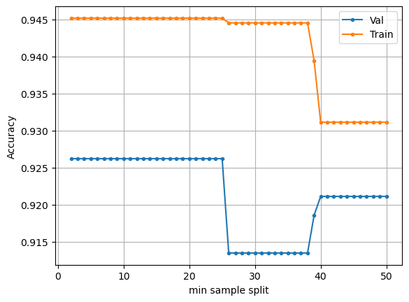

```python
min_sample_split_list = np.arange(2, 50+1, 1)
min_sample_split_list

accuracy_val_list = list()
accuracy_train_list = list()
for min_sample_split in min_sample_split_list:
    clf = DecisionTreeClassifier(
        criterion='gini',
        max_depth=None,
        min_samples_split=min_sample_split,
        min_samples_leaf=12,
        ccp_alpha=0.0,
        random_state=0
    )
    clf.fit(X_train, y_train)

    y_pred = clf.predict(X_val)
    accuracy_val_list.append(accuracy_score(y_val, y_pred))

    y_pred_train = clf.predict(X_train)
    accuracy_train_list.append(accuracy_score(y_train, y_pred_train))

plt.plot(min_sample_split_list, accuracy_val_list, label='Val', marker='.')
plt.plot(min_sample_split_list, accuracy_train_list, label='Train', marker='.')
plt.ylabel('Accuracy')
plt.xlabel('min sample split')
plt.grid('white')
plt.legend()
plt.show()
```

Per concludere, esamineremo come varia l'accuratezza al variare della **massima profondità** dell'albero decisionale. Dall'analisi grafica, sembra che l'accuratezza raggiunga il massimo con valore di profondità 7.

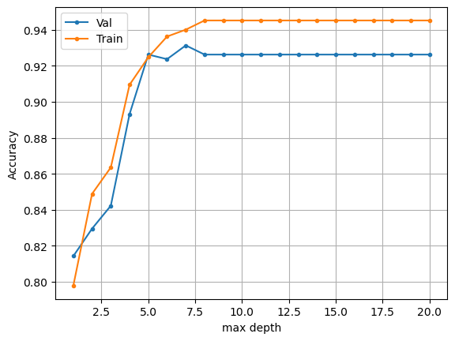

```python
max_depth_list = np.arange(1, 20+1, 1).tolist() + [None]

accuracy_val_list = list()
accuracy_train_list = list()
for max_depth in max_depth_list:
    clf = DecisionTreeClassifier(
        criterion='gini',
        max_depth=max_depth,
        min_samples_split=25,
        min_samples_leaf=12,
        ccp_alpha=0.0,
        random_state=0
    )
    clf.fit(X_train, y_train)

    y_pred = clf.predict(X_val)
    accuracy_val_list.append(accuracy_score(y_val, y_pred))

    y_pred_train = clf.predict(X_train)
    accuracy_train_list.append(accuracy_score(y_train, y_pred_train))

plt.plot(max_depth_list, accuracy_val_list, label='Val', marker='.')
plt.plot(max_depth_list, accuracy_train_list, label='Train', marker='.')
plt.ylabel('Accuracy')
plt.xlabel('max depth')
plt.grid('white')
plt.legend()
plt.show()
```

Proviamo adesso ad usare **RandomizedSearch** che è una tecnica automatica di ottimizzazione della libreria **scikit-learn** per trovare i migliori parametri da impostare per il DecisionTree.

```python
from sklearn.model_selection import RandomizedSearchCV
```

```python
param_dict = {
    'max_depth': np.arange(1, 20+1, 1).tolist(),
    'min_samples_split': np.arange(2, 50+1, 1),
    'min_samples_leaf': np.arange(1, 50+1, 1),
    'ccp_alpha': np.arange(0.0,1, 0.1)
}
```

```python
random = RandomizedSearchCV(clf, param_dict, cv=5, scoring='accuracy', refit=True, n_iter=500, random_state=0)
random.fit(X_train_val, y_train_val)
random.best_params_
```

```
{'min_samples_split': 15,
 'min_samples_leaf': 7,
 'max_depth': 12,
 'ccp_alpha': 0.0}
```

```python
random.best_estimator_
```

```
DecisionTreeClassifier(max_depth=12, min_samples_leaf=7, min_samples_split=15,
                       random_state=0)
```

Si può vedere che i valori trovati da **RandomizedSearch** non sono gli stessi di quelli che abbiamo precendente individuato cambiando un parametro alla volta. Abbiamo deciso di usare i parametri di RandomizedSearch visto che l'algoritmo è più efficiente nel valutare e ottimizzare le diverse combinazione dei tre parametri.

```python
clf = random.best_estimator_
```

```python
from sklearn.tree import plot_tree, export_text
```

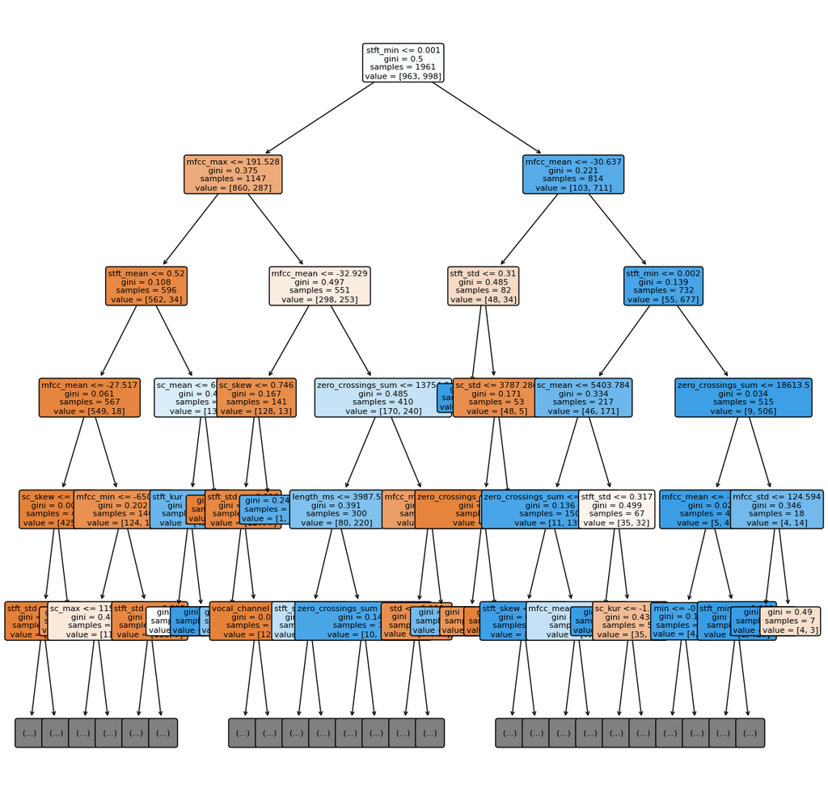

```python
plt.figure(figsize=(14, 14))
plot_tree(clf,
          feature_names=columns,
          filled=True,
          rounded=True,
          fontsize=8,
          max_depth=5
          )
plt.show()
```

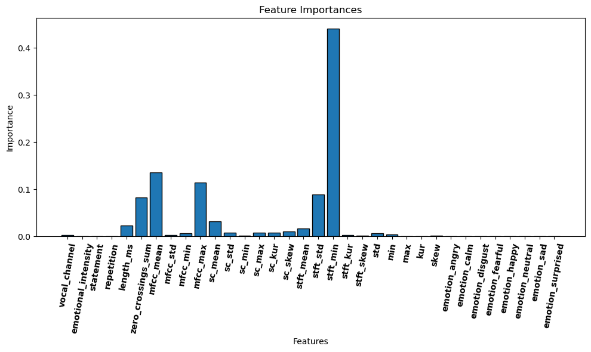

```python
plt.figure(figsize=(10, 6))
plt.bar(columns, clf.feature_importances_, edgecolor='k')
plt.xticks(rotation=80, fontweight='bold')
plt.title('Feature Importances')
plt.xlabel('Features')
plt.ylabel('Importance')
plt.tight_layout()
plt.show()
```

Nel Classification Report stampato sotto, possiamo vedere che l'accuratezza del Decision Tree sul Test set è elevata (0.90), indicando una buona capacità di classificazione generale. Tuttavia, l'analisi di Precision, Recall, F1-Score e Confusion Matrix rivela un piccolo sbilanciamento nelle performance tra le classi. In particolare, il modello mostra una maggiore precisione nel prevedere la classe 0 (F), con meno falsi positivi, ma soffre di un numero più alto di falsi negativi per la stessa classe. Al contrario, per la classe 1 (M), si osserva un incremento dei falsi positivi rispetto ai falsi negativi.

```python
y_pred = clf.predict(X_test)

accuracy_score(y_test, y_pred)
```

```
0.8961303462321792
```

```python
from sklearn.metrics import precision_score, recall_score, f1_score,classification_report
precision = precision_score(y_test, y_pred,average='weighted')
recall = recall_score(y_test, y_pred,average='weighted')
f1 = f1_score(y_test, y_pred,average='weighted')
conf_matrix = confusion_matrix(y_test, y_pred)
y_pred = clf.predict(X_test)
print(classification_report(y_pred, y_test))

y_pred_trainval = clf.predict(X_train_val)

print(classification_report(y_pred_trainval, y_train_val))
```

```
              precision    recall  f1-score   support

         0.0       0.91      0.88      0.90       248
         1.0       0.88      0.91      0.90       243

    accuracy                           0.90       491
   macro avg       0.90      0.90      0.90       491
weighted avg       0.90      0.90      0.90       491

              precision    recall  f1-score   support

         0.0       0.95      0.96      0.96       958
         1.0       0.96      0.96      0.96      1003

    accuracy                           0.96      1961
   macro avg       0.96      0.96      0.96      1961
weighted avg       0.96      0.96      0.96      1961
```

Plottiamo adesso la **ROC** che è uno strumento grafico usato per valutare le prestazioni di un modello predittivo su una variabile target binaria. La curva traccia il tasso di TP rispetto a FP. Calcoliamo l'area sotto alla curva che risulta essere 1 che indica un modello altamente performante. Questo valore è consistente con l'alta accuratezza calcolata in precedenza e implica che il modello predittivo è efficiente sulla variabile target Sex.

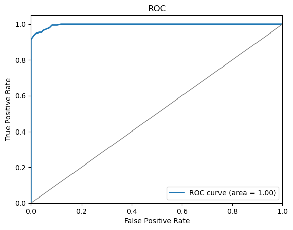

```python
from sklearn.metrics import roc_curve, auc
import matplotlib.pyplot as plt

y_pred = clf.predict_proba(X_val)[:, 1]

fpr, tpr, thresholds = roc_curve(y_val, y_pred)
roc_auc = auc(fpr, tpr)

plt.figure()
plt.plot(fpr, tpr, lw=2, label='ROC curve (area = %0.2f)' % roc_auc)
plt.plot([0, 1], [0, 1], color='gray', lw=1)
plt.xlim([0.0, 1.0])
plt.ylim([0.0, 1.05])
plt.xlabel('False Positive Rate')
plt.ylabel('True Positive Rate')
plt.title('ROC')
plt.legend(loc="lower right")
plt.show()
```

## KNN on Sex

Sebbene il Decision Tree abbia dato ottimi risultati sulla variabile target Sex, esploriamo ora un approccio differente adottando il **K-Nearest Neighbors (KNN)** come classificatore. Questo modello si basa sull'idea che le osservazioni vicine nello spazio dimensionale del dataset tendono ad appartenere alla stessa classe. In pratica, la classificazione di un nuovo campione viene determinata dalla maggioranza delle classi tra i suoi K vicini più prossimi.

Iniziamo con un numero di K=5 (il numero di *vicini* in base ai quali è fatta la classificazione). Il dataset è diviso in due parti: una riservata al **Training & Validation Set** composta dall'80% dei dati e il **Test Set** composto dal 20% dei dati. All'interno della porzione Training & Validation Set, un 20% viene riservato al Validation Set (16% del totale) e il rimanente al Traning Set (64%). Abbiamo scelto questa proporzione in quanto è una di quelle più comunemente usate nei modelli predittivi, ma successivamente andremo a controllare se esistono partizioni che migliorano il modello. La creazione dei due set è stratificata (con il parametro stratify settato a y) e riproducibile (con il parametro random_state=0)

Adottando il KNN, vogliamo valutare come un approccio basato sulla prossimità possa confrontarsi con la metodologia di decisione gerarchica utilizzata dai Decision Tree.

```python
from sklearn.preprocessing import StandardScaler
from sklearn.neighbors import KNeighborsClassifier
from sklearn.metrics import classification_report

target = 'sex'
columns = [c for c in df_noobj.columns if c not in target]

X = df_noobj[columns].values
Y = df_noobj[target].values


scaler = StandardScaler()
X_scaled = scaler.fit_transform(X)

X_train_val, X_test, y_train_val, y_test = train_test_split(X_scaled, Y, test_size=0.2, stratify=Y, random_state=0)
X_train, X_val, y_train, y_val = train_test_split(X_train_val, y_train_val, test_size=0.2, stratify=y_train_val, random_state=0)
print("Training set", X_train.shape, y_train.shape)
print("Validation set", X_val.shape, y_val.shape)
print("Test set", X_test.shape, y_test.shape)
knn = KNeighborsClassifier(n_neighbors=5)
knn.fit(X_train, y_train)
y_pred = knn.predict(X_val)
y_pred_train = knn.predict(X_train)
y_pred_trainval=knn.predict(X_train_val)

print(accuracy_score(y_val, y_pred), accuracy_score(y_train, y_pred_train))
print(classification_report(y_val, y_pred))
print(classification_report(y_pred_trainval, y_train_val))
```

```
Training set (1568, 34) (1568,)
Validation set (393, 34) (393,)
Test set (491, 34) (491,)
0.9338422391857506 0.9464285714285714
              precision    recall  f1-score   support

         0.0       0.95      0.92      0.93       193
         1.0       0.92      0.95      0.94       200

    accuracy                           0.93       393
   macro avg       0.93      0.93      0.93       393
weighted avg       0.93      0.93      0.93       393

              precision    recall  f1-score   support

         0.0       0.95      0.94      0.94       977
         1.0       0.94      0.95      0.94       984

    accuracy                           0.94      1961
   macro avg       0.94      0.94      0.94      1961
weighted avg       0.94      0.94      0.94      1961
```

L'accuratezza risulta già molto alta, ma comunque cerchiamo di ottimizzarla variando il parametro **K**.

```python
acc_val_list = list()
acc_train_list = list()
for k in np.arange(1, 20+1, 1):
    knn = KNeighborsClassifier(n_neighbors=k)
    knn.fit(X_train, y_train)
    y_pred = knn.predict(X_val)
    y_pred_train = knn.predict(X_train)
    acc_val_list.append(accuracy_score(y_val, y_pred))
    acc_train_list.append(accuracy_score(y_train, y_pred_train))
```

Da questo plot sembrerebbe che il miglior numero di K sia 7 però questo potrebbe essere influenzato dalla scelta del training set e del test set che è randomica

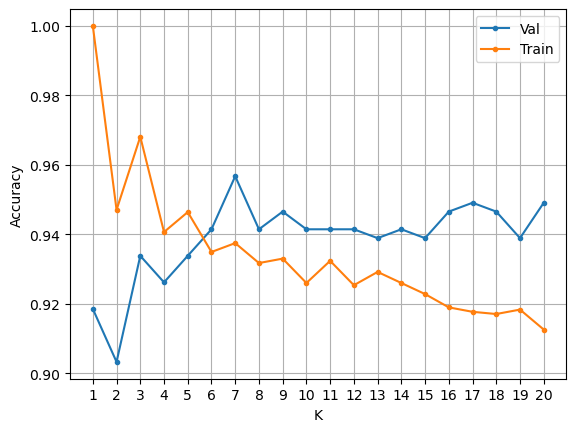

```python
plt.plot(np.arange(1, 20+1, 1), acc_val_list, label='Val', marker='.')
plt.plot(np.arange(1, 20+1, 1), acc_train_list, label='Train', marker='.')
plt.xlabel('K')
plt.ylabel('Accuracy')
plt.xticks(np.arange(1, 20+1, 1))
plt.grid()
plt.legend()
plt.show()
```

Per ovviare al problema della scelta randomica del training set possiamo usare una tecnica chiamata **Repeated Holdout**. Questo metodo prevede la ripetizione della divisione del dataset in Training Set e Test Set per diverse iterazioni, consentendo di valutare la stabilità e l'affidabilità del modello su più suddivisioni dei dati. In questo caso, abbiamo eseguito la valutazione su 5 diverse combinazioni di Training Set e Test Set. Dall'analisi dei risultati, attraverso la visualizzazione, abbiamo identificato che K=7 offre le migliori prestazioni complessive.

```python
nbr_holdout = 5
acc_val_list_all = list()
acc_train_list_all = list()
for i in range(nbr_holdout):

    X_train, X_val, y_train, y_val = train_test_split(X_train_val, y_train_val,
                                                      test_size=0.2,
                                                      stratify=y_train_val,
                                                      random_state=i)

    acc_val_list = list()
    acc_train_list = list()
    for k in np.arange(1, 20+1, 1):
        knn = KNeighborsClassifier(n_neighbors=k)
        knn.fit(X_train, y_train)
        y_pred = knn.predict(X_val)
        y_pred_train = knn.predict(X_train)
        acc_val_list.append(accuracy_score(y_val, y_pred))
        acc_train_list.append(accuracy_score(y_train, y_pred_train))

    acc_val_list_all.append(acc_val_list)
    acc_train_list_all.append(acc_train_list)
```

```python
acc_val_list_all = np.array(acc_val_list_all)
acc_train_list_all = np.array(acc_train_list_all)
```

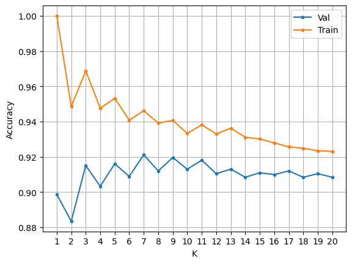

```python
plt.plot(np.arange(1, 20+1, 1), np.mean(acc_val_list_all, axis=0), label='Val', marker='.')
plt.plot(np.arange(1, 20+1, 1), np.mean(acc_train_list_all, axis=0), label='Train', marker='.')
plt.xlabel('K')
plt.ylabel('Accuracy')
plt.xticks(np.arange(1, 20+1, 1))
plt.grid()
plt.legend()
plt.show()
```

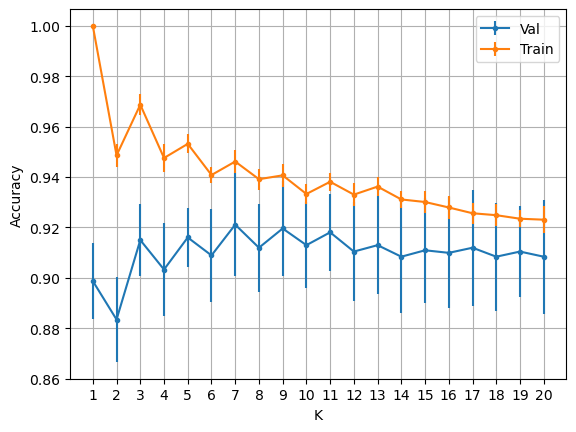

```python
plt.errorbar(x=np.arange(1, 20+1, 1),
             y=np.mean(acc_val_list_all, axis=0),
             yerr=np.std(acc_val_list_all, axis=0),
             label='Val', marker='.')

plt.errorbar(x=np.arange(1, 20+1, 1),
             y=np.mean(acc_train_list_all, axis=0),
             yerr=np.std(acc_train_list_all, axis=0),
             label='Train', marker='.')

plt.xlabel('K')
plt.ylabel('Accuracy')
plt.xticks(np.arange(1, 20+1, 1))
plt.grid()
plt.legend()
plt.show()
```

### Cross Validation

A questo punto è importante però sottolineare che il problema della scelta casuale dei Test Set e Training Set potrebbe persistere, dato che, in teoria, la distribuzione della variabile target potrebbe essere sbilanciata, influenzando così i risultati dei plot precedentemente analizzati. Per mitigare questo potenziale bias, possiamo ricorrere alla tecnica della **Cross Validation**. Questo metodo ci permette di valutare più accuratamente il nostro modello attraverso diverse iterazioni, utilizzando ogni volta diverse suddivisioni del dataset in Training Set e Test Set, assicurando così una più equa rappresentazione della variabile target in ogni fase di valutazione.

Utilizzando i parametri definiti sotto, la funzione cross_val_score organizza X_train_val in 10 sottoinsiemi. Per ogni iterazione di validazione incrociata, 9 di questi sottoinsiemi sono utilizzati per l'addestramento del modello, mentre quello rimanente serve come Test Set. In ogni iterazione, un diverso sottoinsieme è selezionato come test set, mentre i sottoinsiemi restanti costituiscono il training set. Questo processo garantisce che ogni sottoinsieme venga utilizzato almeno una volta come test set. Con k=7 per il nostro classificatore KNN, la funzione procede attraverso tutte le 10 iterazioni possibili, calcolando un valore di accuratezza per ciascuna.

```python
from sklearn.model_selection import cross_val_score
knn = KNeighborsClassifier(n_neighbors=7)
scores = cross_val_score(knn, X_train_val, y_train_val, cv=10)
```

Realizzando un ciclo che varia il valore di K da 1 a 20 e utilizzando la funzione di validazione incrociata per ogni valore, possiamo plottare un grafico che mostra come l'accuratezza varia in funzione di K. Dai risultati ottenuti, K=9 emerge come il valore che massimizza l'accuratezza. Tuttavia, anche K=7 si conferma una scelta valida, mostrando elevate prestazioni.

```python
acc_list_mean = list()
acc_list_std = list()
for k in np.arange(1, 20+1, 1):
    knn = KNeighborsClassifier(n_neighbors=k)
    scores = cross_val_score(knn, X_train_val, y_train_val, cv=10)
    acc_list_mean.append(np.mean(scores))
    acc_list_std.append(np.std(scores))
```

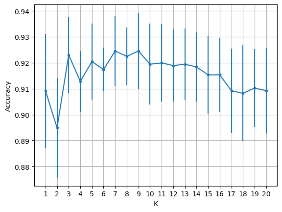

```python
plt.errorbar(x=np.arange(1, 20+1, 1),
             y=acc_list_mean,
             yerr=acc_list_std,
             marker='.')

plt.xlabel('K')
plt.ylabel('Accuracy')
plt.xticks(np.arange(1, 20+1, 1))
plt.grid()
plt.show()
```

Per minimizzare l'impatto della selezione casuale dei set di dati, intrinseco nella funzione cross_val_score, possiamo ripetere il processo di cross-validation più volte. In questo caso, scegliamo di eseguire 5 ripetizioni facendo quindi 2 cicli *for*. Questo approccio aiuta a stabilizzare le stime di accuratezza. K=10 sembra offrire migliori prestazioni complessive, suggerendo che sia il valore ottimale per il nostro classificatore KNN in questo contesto.

```python
nbr_repetitions = 5
acc_list_all = list()
for i in range(nbr_repetitions):
    acc_list = list()
    for k in np.arange(1, 20+1, 1):
        knn = KNeighborsClassifier(n_neighbors=k)
        scores = cross_val_score(knn, X_train_val, y_train_val, cv=10,
                                 scoring='accuracy')
        acc_list.append(scores)

    acc_list_all.append(acc_list)
```

```python
acc_list_all = np.array(acc_list_all)
acc_list_all.shape
acc_list_all.reshape(50, 20)
np.mean(acc_list_all.reshape(50, 20), axis=0)
```

```
array([0.91928934, 0.91071429, 0.92295918, 0.92857143, 0.92091837,
       0.90153061, 0.91020408, 0.91071429, 0.90255102, 0.94846939,
       0.91269036, 0.90714286, 0.91530612, 0.91938776, 0.92040816,
       0.90204082, 0.90510204, 0.91377551, 0.9       , 0.94132653])
```

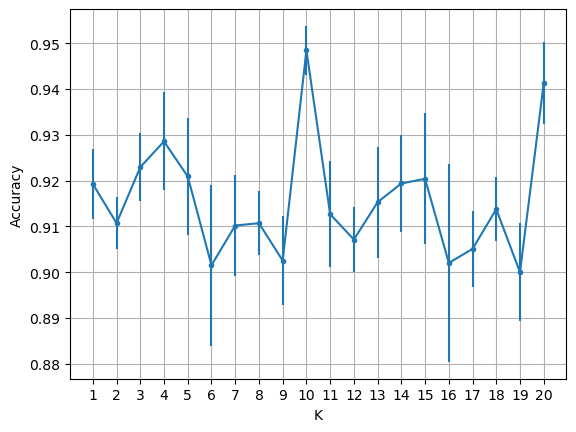

```python
plt.errorbar(x=np.arange(1, 20+1, 1),
             y=np.mean(acc_list_all.reshape(50, 20), axis=0),
             yerr=np.std(acc_list_all.reshape(50, 20), axis=0),
             marker='.')

plt.xlabel('K')
plt.ylabel('Accuracy')
plt.xticks(np.arange(1, 20+1, 1))
plt.grid()
plt.show()
```

Stampiamo i report di classificazione per il Test set e il Training set con K=10. Il metodo predittivo ha un'accuratezza molto alta per entrambi i sessi ma con uno sbilanciamento nella precision e nella recall. Questo sbilanciamento implica che il modello è preciso nel prevedere 0 (Sex=F) con un basso numero di FP (falsi positivi), ma con un numero più alto di FN (falsi negativi) suggerendo una tendenza a sottovalutare questa classe . Per 'M' (Sex=1), si verifica la situazione opposta: ci sono più FP rispetto a FN, indicando una propensione a sovrastimare questa classe.

```python
knn = KNeighborsClassifier(n_neighbors=10)
knn.fit(X_train_val, y_train_val)

y_pred = knn.predict(X_test)
print(classification_report(y_pred, y_test))

y_pred_trainval = knn.predict(X_train_val)
print(classification_report(y_pred_trainval, y_train_val))
```

```
              precision    recall  f1-score   support

         0.0       0.94      0.89      0.91       256
         1.0       0.88      0.94      0.91       235

    accuracy                           0.91       491
   macro avg       0.91      0.91      0.91       491
weighted avg       0.91      0.91      0.91       491

              precision    recall  f1-score   support

         0.0       0.97      0.91      0.94      1028
         1.0       0.91      0.97      0.94       933

    accuracy                           0.94      1961
   macro avg       0.94      0.94      0.94      1961
weighted avg       0.94      0.94      0.94      1961
```

Plottiamo adesso la **ROC** che è uno strumento grafico usato per valutare le prestazioni di un modello predittivo su una variabile target binaria. La curva traccia il tasso di TP rispetto a FP. Calcoliamo l'area sotto alla curva che risulta essere 0.98 che indica un modello altamente performante. Questo valore è consistente con l'alta accuratezza calcolata in precedenza e implica che il modello predittivo è efficiente sulla variabile target Sex.

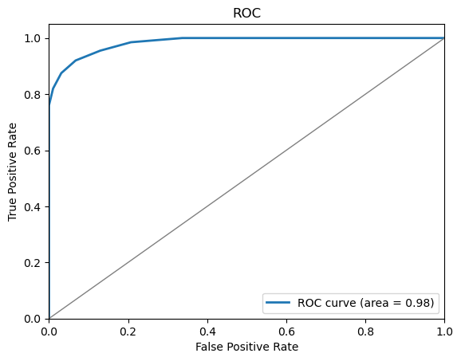

```python
from sklearn.metrics import roc_curve, auc
import matplotlib.pyplot as plt

y_pred = knn.predict_proba(X_val)[:, 1]

fpr, tpr, thresholds = roc_curve(y_val, y_pred)
roc_auc = auc(fpr, tpr)

plt.figure()
plt.plot(fpr, tpr, lw=2, label='ROC curve (area = %0.2f)' % roc_auc)
plt.plot([0, 1], [0, 1], color='gray', lw=1)
plt.xlim([0.0, 1.0])
plt.ylim([0.0, 1.05])
plt.xlabel('False Positive Rate')
plt.ylabel('True Positive Rate')
plt.title('ROC')
plt.legend(loc="lower right")
plt.show()
```

```python
nbr_repetitions = 5
acc_val_list_all = list()
acc_train_list_all = list()
for p in np.arange(0.1, 1.0, 0.1):
    acc_val_list = list()
    acc_train_list = list()
    for i in range(nbr_repetitions):
        index = np.random.choice(np.arange(len(X_train)), int(len(X_train) * p), replace=False)
        knn = KNeighborsClassifier(n_neighbors=10)
        knn.fit(X_train[index], y_train[index])
        y_pred = knn.predict(X_val)
        y_pred_train = knn.predict(X_train[index])
        acc_val_list.append(accuracy_score(y_val, y_pred))
        acc_train_list.append(accuracy_score(y_train[index], y_pred_train))

    acc_val_list_all.append(acc_val_list)
    acc_train_list_all.append(acc_train_list)
```

```python
acc_val_list_all = np.array(acc_val_list_all)
acc_train_list_all = np.array(acc_train_list_all)
```

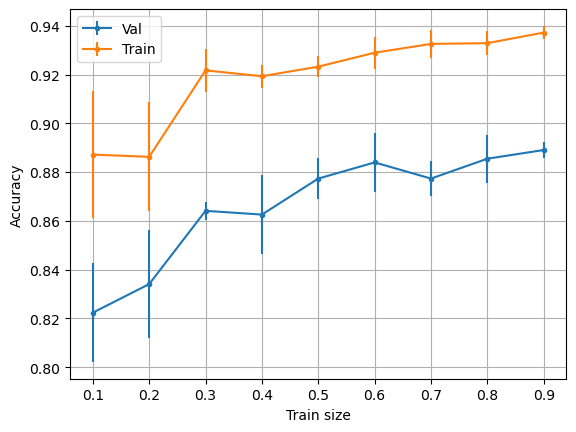

```python
plt.errorbar(x=np.arange(0.1, 1.0, 0.1),
             y=np.mean(acc_val_list_all, axis=1),
             yerr=np.std(acc_val_list_all, axis=1),
             label='Val', marker='.')

plt.errorbar(x=np.arange(0.1, 1.0, 0.1),
             y=np.mean(acc_train_list_all, axis=1),
             yerr=np.std(acc_train_list_all, axis=1),
             label='Train', marker='.')

plt.xlabel('Train size')
plt.ylabel('Accuracy')
plt.xticks(np.arange(0.1, 1.0, 0.1))
plt.grid()
plt.legend()
plt.show()
```

## Decision Tree on Emotion

Per la classificazione della classe Emotion tramite Decision Tree, ripeteremo i passaggi già utilizzati per la classificazione della classe Sex. In questo scenario, tuttavia, per la preparazione dei dati, possiamo evitare l'one-hot encoding per la variabile target 'emotion', optando invece per convertirla direttamente in etichette numeriche da 0 a 7. Questa scelta si giustifica dal fatto che 'emotion' sarà la nostra variabile target in un contesto di classificazione multiclasse, e l'uso di etichette numeriche semplifica il processo senza influire negativamente sull'apprendimento del modello. Le etichette saranno assegnate come segue: **0=angry, 1=calm, 2=disgust, 3=fearful, 4=happy, 5=neutral, 6=sad, 7=surprised.**

```python
dfe=pd.read_csv('A) Data Understanding & Preparation Output.csv', sep=',', skipinitialspace=True)
dfe.head()
```

|  | emotion | vocal_channel | emotional_intensity | statement | repetition | sex | length_ms | zero_crossings_sum | mfcc_mean | mfcc_std | mfcc_min | mfcc_max | sc_mean | sc_std | sc_min | sc_max | sc_kur | sc_skew | stft_mean | stft_std | stft_min | stft_kur | stft_skew | std | min | max | kur | skew |
| --- | --- | --- | --- | --- | --- | --- | --- | --- | --- | --- | --- | --- | --- | --- | --- | --- | --- | --- | --- | --- | --- | --- | --- | --- | --- | --- | --- | --- |
| 0 | fearful | 0.0 | 0.0 | 0.0 | 1.0 | 0.0 | 3737.0 | 16995.0 | -33.485947 | 134.654860 | -755.22345 | 171.69092 | 5792.550744 | 3328.055457 | 0.0 | 13541.959028 | -1.120769 | 0.250940 | 0.415250 | 0.335533 | 0.0 | -1.215025 | 0.403514 | 0.014482 | -0.128632 | 0.138947 | 9.406061 | 0.273153 |
| 1 | angry | 0.0 | 0.0 | 0.0 | 0.0 | 0.0 | 3904.0 | 13906.0 | -29.502108 | 130.485630 | -713.98560 | 205.00770 | 5197.620555 | 4040.931570 | 0.0 | 12000.290443 | -1.531204 | 0.219582 | 0.417488 | 0.352380 | 0.0 | -1.384174 | 0.290905 | 0.020417 | -0.305725 | 0.263062 | 19.564187 | 0.292157 |
| 2 | happy | 0.0 | 1.0 | 0.0 | 1.0 | 0.0 | 4671.0 | 18723.0 | -30.532463 | 126.577110 | -726.06036 | 165.45653 | 4830.743037 | 3332.131300 | 0.0 | 12007.751173 | -1.130153 | 0.436699 | 0.379758 | 0.352270 | 0.0 | -1.242947 | 0.470350 | 0.024317 | -0.137482 | 0.166351 | 4.881241 | 0.302659 |
| 3 | surprised | 0.0 | 0.0 | 1.0 | 0.0 | 0.0 | 3637.0 | 11617.0 | -36.059555 | 159.725160 | -842.94635 | 190.03609 | 5376.446478 | 4053.663073 | 0.0 | 12048.223893 | -1.497765 | 0.098802 | 0.407277 | 0.360552 | 0.0 | -1.445318 | 0.274756 | 0.003561 | -0.027374 | 0.024078 | 13.040259 | -0.081014 |
| 4 | happy | 1.0 | 1.0 | 0.0 | 1.0 | 0.0 | 4404.0 | 15137.0 | -31.405996 | 122.125824 | -700.70276 | 161.13400 | 5146.012474 | 3442.724109 | 0.0 | 12025.582707 | -1.167544 | 0.496066 | 0.415974 | 0.350655 | 0.0 | -1.366742 | 0.318926 | 0.027522 | -0.192169 | 0.242676 | 7.485109 | 0.414872 |

```python
emotion = sorted(dfe['emotion'].unique())
emotion_mapping = dict(zip(emotion, range(0, len(emotion) + 1)))
dfe['Emotion_val'] = dfe['emotion'].map(emotion_mapping).astype(int)
```

```python
dfe.info()
```

```
<class 'pandas.core.frame.DataFrame'>
RangeIndex: 2452 entries, 0 to 2451
Data columns (total 29 columns):
 #   Column               Non-Null Count  Dtype
---  ------               --------------  -----
 0   emotion              2452 non-null   object
 1   vocal_channel        2452 non-null   float64
 2   emotional_intensity  2452 non-null   float64
 3   statement            2452 non-null   float64
 4   repetition           2452 non-null   float64
 5   sex                  2452 non-null   float64
 6   length_ms            2452 non-null   float64
 7   zero_crossings_sum   2452 non-null   float64
 8   mfcc_mean            2452 non-null   float64
 9   mfcc_std             2452 non-null   float64
```

[output cut: 21 more lines]

```python
dfe.dtypes[dfe.dtypes.map(lambda x: x == 'object')]
```

```
emotion    object
dtype: object
```

```python
dfe_noobj = dfe.drop(['emotion'], axis=1)
dfe_noobj.dtypes
```

```
vocal_channel          float64
emotional_intensity    float64
statement              float64
repetition             float64
sex                    float64
length_ms              float64
zero_crossings_sum     float64
mfcc_mean              float64
mfcc_std               float64
mfcc_min               float64
mfcc_max               float64
sc_mean                float64
sc_std                 float64
sc_min                 float64
sc_max                 float64
sc_kur                 float64
sc_skew                float64
stft_mean              float64
stft_std               float64
stft_min               float64
stft_kur               float64
stft_skew              float64
std                    float64
min                    float64
max                    float64
kur                    float64
skew                   float64
Emotion_val              int64
dtype: object
```

```python
dfe_noobj
```

|  | vocal_channel | emotional_intensity | statement | repetition | sex | length_ms | zero_crossings_sum | mfcc_mean | mfcc_std | mfcc_min | mfcc_max | sc_mean | sc_std | sc_min | sc_max | sc_kur | sc_skew | stft_mean | stft_std | stft_min | stft_kur | stft_skew | std | min | max | kur | skew | Emotion_val |
| --- | --- | --- | --- | --- | --- | --- | --- | --- | --- | --- | --- | --- | --- | --- | --- | --- | --- | --- | --- | --- | --- | --- | --- | --- | --- | --- | --- | --- |
| 0 | 0.0 | 0.0 | 0.0 | 1.0 | 0.0 | 3737.0 | 16995.0 | -33.485947 | 134.654860 | -755.22345 | 171.69092 | 5792.550744 | 3328.055457 | 0.000000 | 13541.959028 | -1.120769 | 0.250940 | 0.415250 | 0.335533 | 0.000000 | -1.215025 | 0.403514 | 0.014482 | -0.128632 | 0.138947 | 9.406061 | 0.273153 | 3 |
| 1 | 0.0 | 0.0 | 0.0 | 0.0 | 0.0 | 3904.0 | 13906.0 | -29.502108 | 130.485630 | -713.98560 | 205.00770 | 5197.620555 | 4040.931570 | 0.000000 | 12000.290443 | -1.531204 | 0.219582 | 0.417488 | 0.352380 | 0.000000 | -1.384174 | 0.290905 | 0.020417 | -0.305725 | 0.263062 | 19.564187 | 0.292157 | 0 |
| 2 | 0.0 | 1.0 | 0.0 | 1.0 | 0.0 | 4671.0 | 18723.0 | -30.532463 | 126.577110 | -726.06036 | 165.45653 | 4830.743037 | 3332.131300 | 0.000000 | 12007.751173 | -1.130153 | 0.436699 | 0.379758 | 0.352270 | 0.000000 | -1.242947 | 0.470350 | 0.024317 | -0.137482 | 0.166351 | 4.881241 | 0.302659 | 4 |
| 3 | 0.0 | 0.0 | 1.0 | 0.0 | 0.0 | 3637.0 | 11617.0 | -36.059555 | 159.725160 | -842.94635 | 190.03609 | 5376.446478 | 4053.663073 | 0.000000 | 12048.223893 | -1.497765 | 0.098802 | 0.407277 | 0.360552 | 0.000000 | -1.445318 | 0.274756 | 0.003561 | -0.027374 | 0.024078 | 13.040259 | -0.081014 | 7 |
| 4 | 1.0 | 1.0 | 0.0 | 1.0 | 0.0 | 4404.0 | 15137.0 | -31.405996 | 122.125824 | -700.70276 | 161.13400 | 5146.012474 | 3442.724109 | 0.000000 | 12025.582707 | -1.167544 | 0.496066 | 0.415974 | 0.350655 | 0.000000 | -1.366742 | 0.318926 | 0.027522 | -0.192169 | 0.242676 | 7.485109 | 0.414872 | 4 |
| ... | ... | ... | ... | ... | ... | ... | ... | ... | ... | ... | ... | ... | ... | ... | ... | ... | ... | ... | ... | ... | ... | ... | ... | ... | ... | ... | ... | ... |
| 2447 | 0.0 | 1.0 | 1.0 | 0.0 | 1.0 | 4605.0 | 9871.0 | -30.225578 | 158.845500 | -855.92420 | 208.18497 | 5886.647366 | 4114.260257 | 0.000000 | 12210.517144 | -1.588861 | 0.184390 | 0.573838 | 0.304496 | 0.000000 | -1.075888 | -0.310088 | 0.005260 | -0.039856 | 0.052399 | 9.551363 | 0.759247 | 1 |
| 2448 | 0.0 | 0.0 | 0.0 | 0.0 | 1.0 | 4171.0 | 8963.0 | -31.160332 | 157.499700 | -825.37410 | 220.79490 | 6602.742127 | 4191.727090 | 0.000000 | 12064.561791 | -1.614582 | -0.113920 | 0.591010 | 0.306333 | 0.000000 | -1.026071 | -0.408018 | 0.006836 | -0.064178 | 0.084045 | 22.517991 | 1.073633 | 1 |
| 2449 | 1.0 | 1.0 | 0.0 | 1.0 | 1.0 | 5239.0 | 9765.0 | -26.135280 | 138.133210 | -768.36536 | 235.53938 | 4654.156076 | 4231.511986 | 0.000000 | 12207.179884 | -1.337419 | 0.619346 | 0.467994 | 0.347843 | 0.000000 | -1.473789 | 0.130310 | 0.015384 | -0.093079 | 0.097260 | 4.964319 | -0.005821 | 6 |
| 2450 | 0.0 | 0.0 | 1.0 | 0.0 | 1.0 | 3737.0 | 9716.0 | -28.242815 | 159.943400 | -868.09576 | 219.84350 | 5524.736973 | 3596.031841 | 760.822547 | 11981.912464 | -1.465594 | 0.206481 | 0.578854 | 0.308684 | 0.001565 | -1.277117 | -0.242668 | 0.005182 | -0.057556 | 0.052002 | 13.855588 | -0.110966 | 7 |
| 2451 | 1.0 | 0.0 | 0.0 | 1.0 | 1.0 | 3837.0 | 9427.0 | -29.019236 | 149.188950 | -799.51010 | 219.52780 | 6082.676123 | 3963.725117 | 0.000000 | 12199.773419 | -1.501387 | 0.147574 | 0.554946 | 0.320787 | 0.000000 | -1.257666 | -0.237757 | 0.010001 | -0.081512 | 0.103027 | 12.973181 | 1.032081 | 5 |

2452 rows × 28 columns

Scegliamo come variabile target l'attributo "Emotion_val" e prendiamo tutte le altre per addestrare il Decision Tree.

```python
target = 'Emotion_val'
columns = [c for c in dfe_noobj.columns if c not in target]
```

```python
columns
```

```
['vocal_channel',
 'emotional_intensity',
 'statement',
 'repetition',
 'sex',
 'length_ms',
 'zero_crossings_sum',
 'mfcc_mean',
 'mfcc_std',
 'mfcc_min',
 'mfcc_max',
 'sc_mean',
 'sc_std',
 'sc_min',
 'sc_max',
 'sc_kur',
 'sc_skew',
 'stft_mean',
 'stft_std',
 'stft_min',
 'stft_kur',
 'stft_skew',
 'std',
 'min',
 'max',
 'kur',
 'skew']
```

```python
X = dfe_noobj[columns].values
y = dfe_noobj[target].values
```

```python
from sklearn.model_selection import train_test_split
```

```python
X_train_val, X_test, y_train_val, y_test = train_test_split(X, y, test_size=0.2, stratify=y, random_state=0)
```

```python
X_train, X_val, y_train, y_val = train_test_split(X_train_val, y_train_val, test_size=0.2, stratify=y_train_val, random_state=0)
```

```python
from sklearn.tree import DecisionTreeClassifier
```

```python
from sklearn.metrics import accuracy_score, confusion_matrix
```

```python
clf = DecisionTreeClassifier(
    criterion='gini',
    max_depth=None,
    min_samples_split=2,
    min_samples_leaf=1,
    ccp_alpha=0.0,
    random_state=0
)
clf.fit(X_train, y_train)

y_pred = clf.predict(X_val)
accuracy_score(y_val, y_pred)
```

```
0.4071246819338422
```

```python
confusion_matrix(y_val, y_pred)
```

```
array([[36,  0,  3, 10,  2,  2,  5,  2],
       [ 2, 28,  5,  3,  6,  1, 14,  1],
       [ 2,  5,  9,  4,  0,  3,  6,  2],
       [ 9,  4,  1, 20, 11,  4,  2,  9],
       [10,  4,  3,  6, 19,  2, 12,  4],
       [ 1,  5,  0,  5,  3, 10,  6,  0],
       [ 0, 11, 11,  2,  3,  6, 27,  1],
       [ 0,  6,  2,  4,  3,  2,  3, 11]])
```

```python
accuracy_mean_list = list()
accuracy_std_list = list()
for p in np.arange(0.1, 1.0, 0.1):
    accuracy_list_p = list()
    for i in range(0, 10):
        index = np.random.choice(np.arange(0, len(X_train)), int(len(X_train) * p), replace=False)
        clf = DecisionTreeClassifier(
            criterion='gini',
            max_depth=None,
            min_samples_split=2,
            min_samples_leaf=1,
            ccp_alpha=0.0,
            random_state=0
        )
        clf.fit(X_train[index], y_train[index])

        y_pred = clf.predict(X_val)
        accuracy_list_p.append(accuracy_score(y_val, y_pred))
    accuracy_mean_list.append(np.mean(accuracy_list_p))
    accuracy_std_list.append(np.std(accuracy_list_p))
```

[figure not shown]

```python
accuracy_mean_list.append(0.7967914438502673)
accuracy_std_list.append(0.0)

plt.errorbar(x=np.arange(0.1, 1.1, 0.1), y=accuracy_mean_list,
             yerr=accuracy_std_list, marker='o')
plt.axhline(y=0.7967914438502673, color='r')
plt.ylabel('Accuracy')
plt.xlabel('X_train size')
plt.show()
```

Come per l'analisi effettuata per la classificazione del sesso tramite Decision Tree, abbiamo proceduto a plottare l'effetto del parametro **min_samples_leaf** sull'accuratezza del modello. Questo parametro determina il numero minimo di campioni che devono essere presenti in una foglia. Dai nostri risultati, emerge che impostare min_samples_leaf a 12 ottimizza l'accuratezza del modello. Generalmente però bisogna sottolineare che un numero più alto di questo valore produce un metodo più robusto.

```python
accuracy_val_list = list()
accuracy_train_list = list()
for min_sample_leaf in range(1,51):
    clf = DecisionTreeClassifier(
        criterion='gini',
        max_depth=None,
        min_samples_split=2,
        min_samples_leaf=min_sample_leaf,
        ccp_alpha=0.0,
        random_state=0
    )
    clf.fit(X_train, y_train)

    y_pred = clf.predict(X_val)
    accuracy_val_list.append(accuracy_score(y_val, y_pred))

    y_pred_train = clf.predict(X_train)
    accuracy_train_list.append(accuracy_score(y_train, y_pred_train))
```

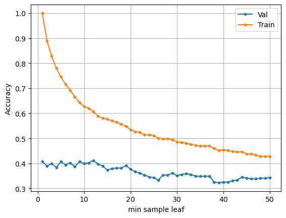

```python
plt.plot(min_sample_leaf_list, accuracy_val_list, label='Val', marker='.')
plt.plot(min_sample_leaf_list, accuracy_train_list, label='Train', marker='.')
plt.ylabel('Accuracy')
plt.xlabel('min sample leaf')
plt.grid('white')
plt.legend()
plt.show()
```

Abbiamo condotto un'ulteriore analisi per determinare come il parametro **min_samples_split** (il numero minimo di campioni che un nodo deve avere per essere considerato per la divisione) influisca sull'accuratezza del nostro modello. Dalla visualizzazione, possiamo osservare che i valori <=24 offrano le migliori prestazioni in termini di accuratezza.

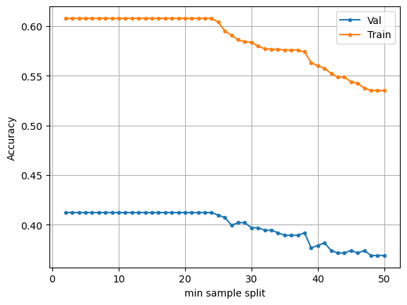

```python
min_sample_split_list = np.arange(2, 50+1, 1)
min_sample_split_list

accuracy_val_list = list()
accuracy_train_list = list()
for min_sample_split in min_sample_split_list:
    clf = DecisionTreeClassifier(
        criterion='gini',
        max_depth=None,
        min_samples_split=min_sample_split,
        min_samples_leaf=12,
        ccp_alpha=0.0,
        random_state=0
    )
    clf.fit(X_train, y_train)

    y_pred = clf.predict(X_val)
    accuracy_val_list.append(accuracy_score(y_val, y_pred))

    y_pred_train = clf.predict(X_train)
    accuracy_train_list.append(accuracy_score(y_train, y_pred_train))

plt.plot(min_sample_split_list, accuracy_val_list, label='Val', marker='.')
plt.plot(min_sample_split_list, accuracy_train_list, label='Train', marker='.')
plt.ylabel('Accuracy')
plt.xlabel('min sample split')
plt.grid('white')
plt.legend()
plt.show()
```

Abbiamo ripetuto l'analisi precedente per valutare come la massima profondità dell'albero **(max_depth)** influisca sull'accuratezza del nostro modello di classificazione. Plottando l'accuratezza del modello in funzione di diverse profondità massime, abbiamo identificato che il valore di max_depth pari a 10 offre il miglior risultato in termini di accuratezza. Questo suggerisce che un albero con una profondità massima di 10 è sufficientemente complesso da catturare le relazioni significative nei dati senza andare in overfitting.

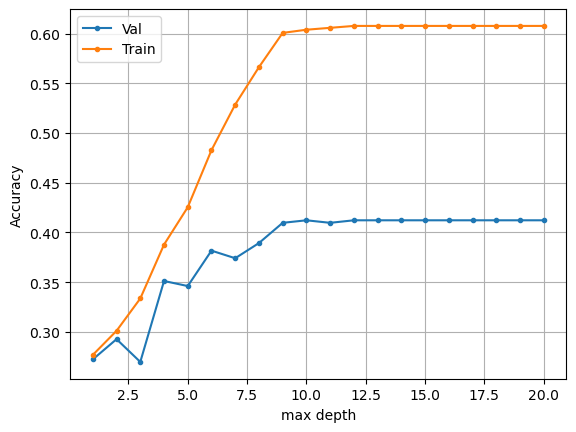

```python
max_depth_list = np.arange(1, 20+1, 1).tolist() + [None]

accuracy_val_list = list()
accuracy_train_list = list()
for max_depth in max_depth_list:
    clf = DecisionTreeClassifier(
        criterion='gini',
        max_depth=max_depth,
        min_samples_split=24,
        min_samples_leaf=12,
        ccp_alpha=0.0,
        random_state=0
    )
    clf.fit(X_train, y_train)

    y_pred = clf.predict(X_val)
    accuracy_val_list.append(accuracy_score(y_val, y_pred))

    y_pred_train = clf.predict(X_train)
    accuracy_train_list.append(accuracy_score(y_train, y_pred_train))

plt.plot(max_depth_list, accuracy_val_list, label='Val', marker='.')
plt.plot(max_depth_list, accuracy_train_list, label='Train', marker='.')
plt.ylabel('Accuracy')
plt.xlabel('max depth')
plt.grid('white')
plt.legend()
plt.show()
```

Procederemo ora all'utilizzo di **RandomizedSearchCV**, una tecnica di ottimizzazione automatica fornita da scikit-learn, per identificare la migliore combinazione di parametri per il nostro modello Decision Tree. Diversamente dalla ricerca esaustiva su griglia (GridSearchCV), RandomizedSearchCV riduce il tempo computazionale, ma permette comunque di esplorare un ampio spazio dei parametri. Questo approccio è particolarmente utile per ottimizzare modelli complessi su grandi set di dati, poiché consente di trovare una buona combinazione di parametri in modo più efficiente. Imposteremo un range di valori per ciascun parametro di interesse e lasceremo che RandomizedSearchCV determini la combinazione ottimale attraverso validazione incrociata.

```python
from sklearn.model_selection import RandomizedSearchCV
```

```python
clf = DecisionTreeClassifier(
        criterion='gini',
        max_depth=10,
        min_samples_split=10,
        min_samples_leaf=11,
        ccp_alpha=0.0,
        random_state=0)
```

```python
param_dict = {
    'max_depth': np.arange(1, 20+1, 1).tolist(),
    'min_samples_split': np.arange(2, 50+1, 1),
    'min_samples_leaf': np.arange(1, 50+1, 1),
    'ccp_alpha': np.arange(0.0,1, 0.1)
}
```

```python
random = RandomizedSearchCV(clf, param_dict, cv=5, scoring='accuracy', refit=True, n_iter=500, random_state=0)
random.fit(X_train_val, y_train_val)
random.best_params_
```

```
{'min_samples_split': 6,
 'min_samples_leaf': 5,
 'max_depth': 16,
 'ccp_alpha': 0.0}
```

Possiamo vedere che i valori dei parametri individuati tramite **RandomizedSearchCV** non corrispondono a quelli precedentemente identificati variando un parametro alla volta. Questa differenza sottolinea l'efficacia di RandomizedSearchCV nell'esplorare le varie combinazioni di parametri in modo più ampio e sistematico, considerando le interazioni tra più parametri contemporaneamente. Di conseguenza, abbiamo deciso di adottare i parametri suggeriti da RandomizedSearchCV per il nostro modello Decision Tree.

```python
clf = random.best_estimator_
```

```python
from sklearn.tree import plot_tree, export_text
```

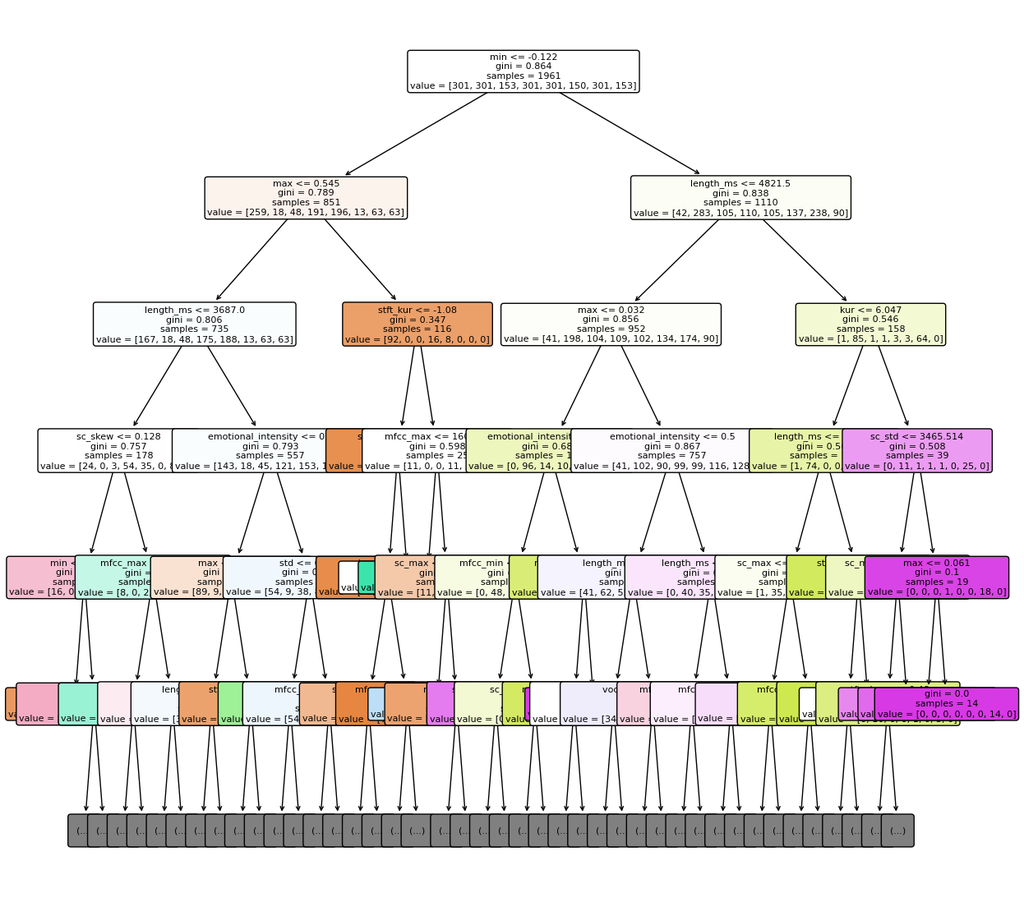

```python
plt.figure(figsize=(14, 14))
plot_tree(clf,
          feature_names=columns,
          filled=True,
          rounded=True,
          fontsize=8,
          max_depth=5
          )
plt.show()
```

Utilizzando una barchart, abbiamo visualizzato **l'importanza delle diverse features** del nostro dataset nell'influenzare la previsione della variabile 'Emotion' con il modello di Decision Tree. L'analisi rivela che la feature 'length_ms' è la più influente, seguita da 'min' e 'max'. Queste informazioni sono state ottenute analizzando quanto ogni feature sia efficace nel separare le diverse classi di 'Emotion' nel dataset.

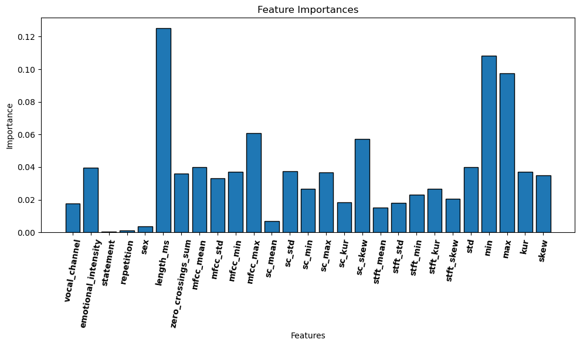

```python
plt.figure(figsize=(10, 6))
plt.bar(columns, clf.feature_importances_, edgecolor='k')
plt.xticks(rotation=80, fontweight='bold')
plt.title('Feature Importances')
plt.xlabel('Features')
plt.ylabel('Importance')
plt.tight_layout()
plt.show()
```

```python
y_pred = clf.predict(X_test)
y_pred_trainval=clf.predict(X_train_val)

accuracy_score(y_test, y_pred)
```

```
0.42769857433808556
```

```python
from sklearn.metrics import precision_score, recall_score, f1_score
precision = precision_score(y_test, y_pred,average='weighted')
recall = recall_score(y_test, y_pred,average='weighted')
f1 = f1_score(y_test, y_pred,average='weighted')
conf_matrix = confusion_matrix(y_test, y_pred)

print("Precision:", precision)
print("Recall:", recall)
print("F1 Score:", f1)
print("Confusion Matrix:", conf_matrix)
print(classification_report(y_pred, y_test))

print(classification_report(y_pred_trainval, y_train_val))
```

```
Precision: 0.43002924888387906
Recall: 0.42769857433808556
F1 Score: 0.4246737062512508
Confusion Matrix: [[47  4  2  9  9  2  0  2]
 [ 1 40  5  5  1  2 19  2]
 [ 2  8 12  1  2  0 14  0]
 [18  6  3 23  9  7  6  3]
 [11  4  3 10 29  8  7  3]
 [ 0  8  0  1  7 16  6  0]
 [ 1 26  7  5  2  5 28  1]
 [ 3  1  2  6  7  2  3 15]]
              precision    recall  f1-score   support

           0       0.63      0.57      0.59        83
           1       0.53      0.41      0.47        97
           2       0.31      0.35      0.33        34
           3       0.31      0.38      0.34        60
           4       0.39      0.44      0.41        66
           5       0.42      0.38      0.40        42
           6       0.37      0.34      0.35        83
           7       0.38      0.58      0.46        26

    accuracy                           0.43       491
   macro avg       0.42      0.43      0.42       491
weighted avg       0.44      0.43      0.43       491

              precision    recall  f1-score   support

           0       0.84      0.79      0.82       317
           1       0.86      0.75      0.80       347
           2       0.69      0.70      0.69       150
           3       0.71      0.77      0.74       279
           4       0.72      0.74      0.73       293
           5       0.70      0.75      0.72       140
           6       0.72      0.74      0.73       292
           7       0.70      0.75      0.72       143

    accuracy                           0.75      1961
   macro avg       0.74      0.75      0.74      1961
weighted avg       0.76      0.75      0.75      1961
```

Visualizziamo anche la Confusion Matrix e plottiamo la ROC curve per questo modello predittivo

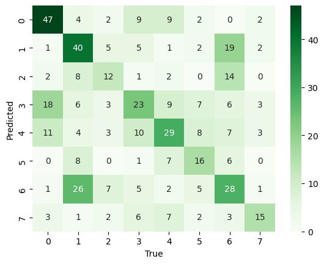

```python
import seaborn as sns
cf = confusion_matrix(y_test, y_pred)
sns.heatmap(cf, annot=True, cmap="Greens")
plt.xlabel("True")
plt.ylabel("Predicted")
plt.show()
```

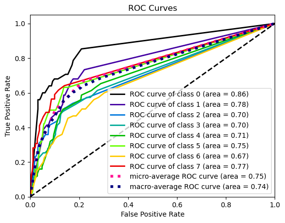

```python
import scikitplot
y_pred_proba = clf.predict_proba(X_test)
scikitplot.metrics.plot_roc(y_test,y_pred_proba)
```

## KNN on Emotion

Per l'analisi delle 'Emotion' con il modello KNN, applicheremo la stessa procedura e gli stessi passi precedentemente discussi e analizzati nella classificazione della variabile Sex.

```python
from sklearn.neighbors import KNeighborsClassifier
from sklearn.metrics import classification_report

target = 'Emotion_val'
columns = [c for c in dfe_noobj.columns if c not in target]

X = dfe_noobj[columns].values
Y = dfe_noobj[target].values


scaler = StandardScaler()
X_scaled = scaler.fit_transform(X)

X_train_val, X_test, y_train_val, y_test = train_test_split(X_scaled, Y, test_size=0.3, stratify=Y, random_state=0)
X_train, X_val, y_train, y_val = train_test_split(X_train_val, y_train_val, test_size=0.3, stratify=y_train_val, random_state=0)
print("Training set", X_train.shape, y_train.shape)
print("Validation set", X_val.shape, y_val.shape)
print("Test set", X_test.shape, y_test.shape)
knn = KNeighborsClassifier(n_neighbors=5)
knn.fit(X_train, y_train)
y_pred_val = knn.predict(X_val)
y_pred_train = knn.predict(X_train)
y_pred=knn.predict(X_test)


print("Test set:\n",classification_report(y_pred, y_test))
print(accuracy_score(y_val, y_pred_val), accuracy_score(y_train, y_pred_train))
print(classification_report(y_val, y_pred_val))
```

```
Training set (1201, 27) (1201,)
Validation set (515, 27) (515,)
Test set (736, 27) (736,)
Test set:
               precision    recall  f1-score   support

           0       0.58      0.40      0.47       167
           1       0.54      0.39      0.45       157
           2       0.22      0.25      0.24        52
           3       0.27      0.33      0.30        93
           4       0.25      0.26      0.25       108
           5       0.25      0.24      0.25        58
           6       0.17      0.35      0.23        54
           7       0.33      0.40      0.37        47

    accuracy                           0.34       736
   macro avg       0.33      0.33      0.32       736
weighted avg       0.39      0.34      0.35       736

0.3300970873786408 0.5736885928393006
              precision    recall  f1-score   support

           0       0.41      0.61      0.49        79
           1       0.41      0.48      0.44        79
           2       0.34      0.28      0.31        40
           3       0.25      0.23      0.24        79
           4       0.24      0.27      0.25        79
           5       0.34      0.25      0.29        40
           6       0.31      0.22      0.26        79
           7       0.24      0.17      0.20        40

    accuracy                           0.33       515
   macro avg       0.32      0.31      0.31       515
weighted avg       0.32      0.33      0.32       515
```

```python
acc_val_list = list()
acc_train_list = list()
for k in np.arange(1, 20+1, 1):
    knn = KNeighborsClassifier(n_neighbors=k)
    knn.fit(X_train, y_train)
    y_pred = knn.predict(X_val)
    y_pred_train = knn.predict(X_train)
    acc_val_list.append(accuracy_score(y_val, y_pred))
    acc_train_list.append(accuracy_score(y_train, y_pred_train))
```

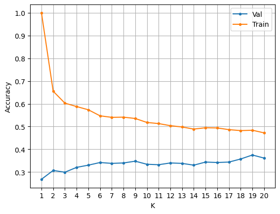

```python
plt.plot(np.arange(1, 20+1, 1), acc_val_list, label='Val', marker='.')
plt.plot(np.arange(1, 20+1, 1), acc_train_list, label='Train', marker='.')
plt.xlabel('K')
plt.ylabel('Accuracy')
plt.xticks(np.arange(1, 20+1, 1))
plt.grid()
plt.legend()
plt.show()
```

```python
nbr_holdout = 5
acc_val_list_all = list()
acc_train_list_all = list()
for i in range(nbr_holdout):

    X_train, X_val, y_train, y_val = train_test_split(X_train_val, y_train_val,
                                                      test_size=0.3,
                                                      stratify=y_train_val,
                                                      random_state=i)

    acc_val_list = list()
    acc_train_list = list()
    for k in np.arange(1, 20+1, 1):
        knn = KNeighborsClassifier(n_neighbors=k)
        knn.fit(X_train, y_train)
        y_pred = knn.predict(X_val)
        y_pred_train = knn.predict(X_train)
        acc_val_list.append(accuracy_score(y_val, y_pred))
        acc_train_list.append(accuracy_score(y_train, y_pred_train))

    acc_val_list_all.append(acc_val_list)
    acc_train_list_all.append(acc_train_list)
```

```python
acc_val_list_all = np.array(acc_val_list_all)
acc_train_list_all = np.array(acc_train_list_all)
```

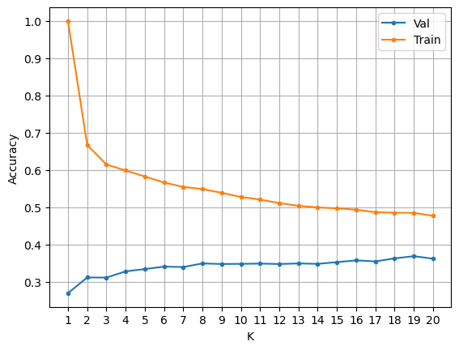

```python
plt.plot(np.arange(1, 20+1, 1), np.mean(acc_val_list_all, axis=0), label='Val', marker='.')
plt.plot(np.arange(1, 20+1, 1), np.mean(acc_train_list_all, axis=0), label='Train', marker='.')
plt.xlabel('K')
plt.ylabel('Accuracy')
plt.xticks(np.arange(1, 20+1, 1))
plt.grid()
plt.legend()
plt.show()
```

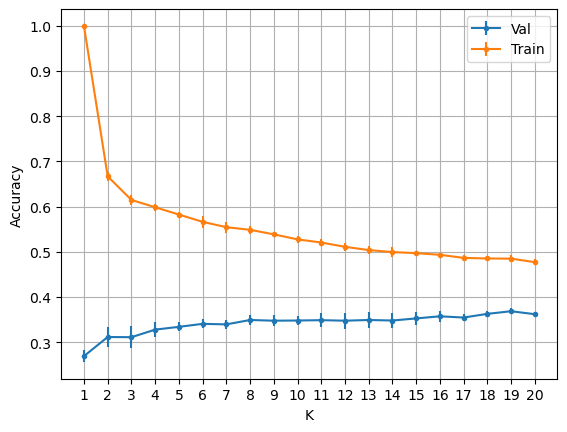

```python
plt.errorbar(x=np.arange(1, 20+1, 1),
             y=np.mean(acc_val_list_all, axis=0),
             yerr=np.std(acc_val_list_all, axis=0),
             label='Val', marker='.')

plt.errorbar(x=np.arange(1, 20+1, 1),
             y=np.mean(acc_train_list_all, axis=0),
             yerr=np.std(acc_train_list_all, axis=0),
             label='Train', marker='.')

plt.xlabel('K')
plt.ylabel('Accuracy')
plt.xticks(np.arange(1, 20+1, 1))
plt.grid()
plt.legend()
plt.show()
```

### Cross Validation

```python
from sklearn.model_selection import cross_val_score
knn = KNeighborsClassifier(n_neighbors=5)
scores = cross_val_score(knn, X_train_val, y_train_val, cv=10)
```

```python
acc_list_mean = list()
acc_list_std = list()
for k in np.arange(1, 20+1, 1):
    knn = KNeighborsClassifier(n_neighbors=k)
    scores = cross_val_score(knn, X_train_val, y_train_val, cv=10)
    acc_list_mean.append(np.mean(scores))
    acc_list_std.append(np.std(scores))
```

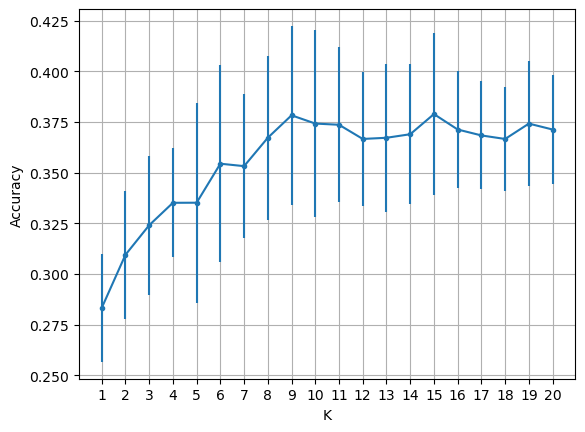

```python
plt.errorbar(x=np.arange(1, 20+1, 1),
             y=acc_list_mean,
             yerr=acc_list_std,
             marker='.')

plt.xlabel('K')
plt.ylabel('Accuracy')
plt.xticks(np.arange(1, 20+1, 1))
plt.grid()
plt.show()
```

Dall'analisi del grafico plottato sotto, il numero migliore di K per il modello KNN su Emotion sembrano essere 8 e 18. Abbiamo deciso di scegliere K=18 per il nostro modello predittivo perché dal grafico sembra avere una variazione più bassa.

```python
nbr_repetitions = 5
acc_list_all = list()
for i in range(nbr_repetitions):
    acc_list = list()
    for k in np.arange(1, 20+1, 1):
        knn = KNeighborsClassifier(n_neighbors=k)
        scores = cross_val_score(knn, X_train_val, y_train_val, cv=10, #k-fold
                                 scoring='accuracy')
        acc_list.append(scores)

    acc_list_all.append(acc_list)
```

```python
acc_list_all = np.array(acc_list_all)
acc_list_all.shape
acc_list_all.reshape(50, 20)
np.mean(acc_list_all.reshape(50, 20), axis=0)
```

```
array([0.35697674, 0.34011628, 0.32267442, 0.3005814 , 0.3622093 ,
       0.34593023, 0.38596491, 0.41637427, 0.37192982, 0.33333333,
       0.36860465, 0.34883721, 0.32151163, 0.31104651, 0.35988372,
       0.34883721, 0.38304094, 0.41637427, 0.38304094, 0.34385965])
```

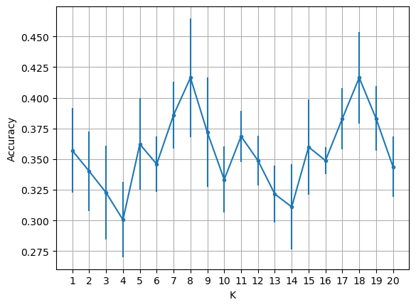

```python
plt.errorbar(x=np.arange(1, 20+1, 1),
             y=np.mean(acc_list_all.reshape(50, 20), axis=0),
             yerr=np.std(acc_list_all.reshape(50, 20), axis=0),
             marker='.')

plt.xlabel('K')
plt.ylabel('Accuracy')
plt.xticks(np.arange(1, 20+1, 1))
plt.grid()
plt.show()
```

```python
knn = KNeighborsClassifier(n_neighbors=18)
knn.fit(X_train_val, y_train_val)

y_pred = knn.predict(X_test)
print("Test set:\n",classification_report(y_pred, y_test))

y_pred_trainval = knn.predict(X_train_val)
print(classification_report(y_pred_trainval, y_train_val))
```

```
Test set:
               precision    recall  f1-score   support

           0       0.65      0.61      0.63       122
           1       0.50      0.41      0.45       135
           2       0.36      0.38      0.37        55
           3       0.38      0.42      0.40       102
           4       0.23      0.23      0.23       112
           5       0.34      0.28      0.31        68
           6       0.19      0.30      0.23        70
           7       0.54      0.43      0.48        72

    accuracy                           0.40       736
   macro avg       0.40      0.38      0.39       736
weighted avg       0.42      0.40      0.40       736

              precision    recall  f1-score   support

           0       0.74      0.63      0.68       308
           1       0.62      0.54      0.58       306
           2       0.35      0.42      0.38       112
           3       0.49      0.47      0.48       274
           4       0.47      0.49      0.48       255
           5       0.45      0.40      0.43       149
           6       0.31      0.46      0.37       176
           7       0.40      0.40      0.40       136

    accuracy                           0.50      1716
   macro avg       0.48      0.48      0.47      1716
weighted avg       0.52      0.50      0.50      1716
```

```python
nbr_repetitions = 5
acc_val_list_all = list()
acc_train_list_all = list()
for p in np.arange(0.1, 1.0, 0.1):
    acc_val_list = list()
    acc_train_list = list()
    for i in range(nbr_repetitions):
        index = np.random.choice(np.arange(len(X_train)), int(len(X_train) * p), replace=False)
        knn = KNeighborsClassifier(n_neighbors=10)
        knn.fit(X_train[index], y_train[index])
        y_pred = knn.predict(X_val)
        y_pred_train = knn.predict(X_train[index])
        acc_val_list.append(accuracy_score(y_val, y_pred))
        acc_train_list.append(accuracy_score(y_train[index], y_pred_train))

    acc_val_list_all.append(acc_val_list)
    acc_train_list_all.append(acc_train_list)
```

```python
acc_val_list_all = np.array(acc_val_list_all)
acc_train_list_all = np.array(acc_train_list_all)
```

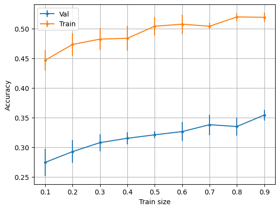

```python
plt.errorbar(x=np.arange(0.1, 1.0, 0.1),
             y=np.mean(acc_val_list_all, axis=1),
             yerr=np.std(acc_val_list_all, axis=1),
             label='Val', marker='.')

plt.errorbar(x=np.arange(0.1, 1.0, 0.1),
             y=np.mean(acc_train_list_all, axis=1),
             yerr=np.std(acc_train_list_all, axis=1),
             label='Train', marker='.')

plt.xlabel('Train size')
plt.ylabel('Accuracy')
plt.xticks(np.arange(0.1, 1.0, 0.1))
plt.grid()
plt.legend()
plt.show()
```

Nelle celle sotto abbiamo disegnato la confusion matrix per questo modello e la ROC curve

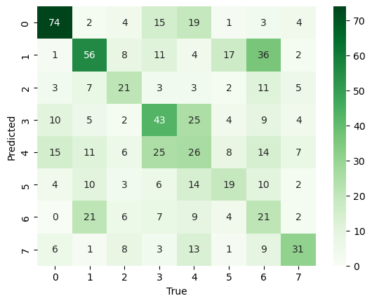

```python
import seaborn as sns
cf = confusion_matrix(y_pred, y_test)
sns.heatmap(cf, annot=True, cmap="Greens")
plt.xlabel("True")
plt.ylabel("Predicted")
plt.show()
```

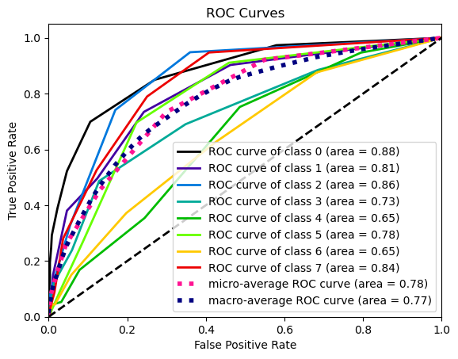

```python
import scikitplot
y_pred_proba = knn.predict_proba(X_test)
scikitplot.metrics.plot_roc(y_test,y_pred_proba)
```